# Reproducible Agronomy

August 3, 2016

## Why

- If you have to do something once, you are going to have to do it 1000 times
- analysis is iterative
- requests/collaborators are unpredictable
- data grows
- If you can't reproduce what you did, it's impossible to find the mistakes
- If you can't reproduce what you did, it is not credible

## Why

- If you can reproduce what you did, others can too
- They can either use the information to perform similar analyses, or build upon all the work you did

## The best thing you can do is to start every project with the goal and mindset of reproducibility

## Steps to reproducible research

Karl Broman, Department of Biostatistics & Medical Informatics  
University of Wisconsin-Madison  
kbroman.org  
@kwbroman

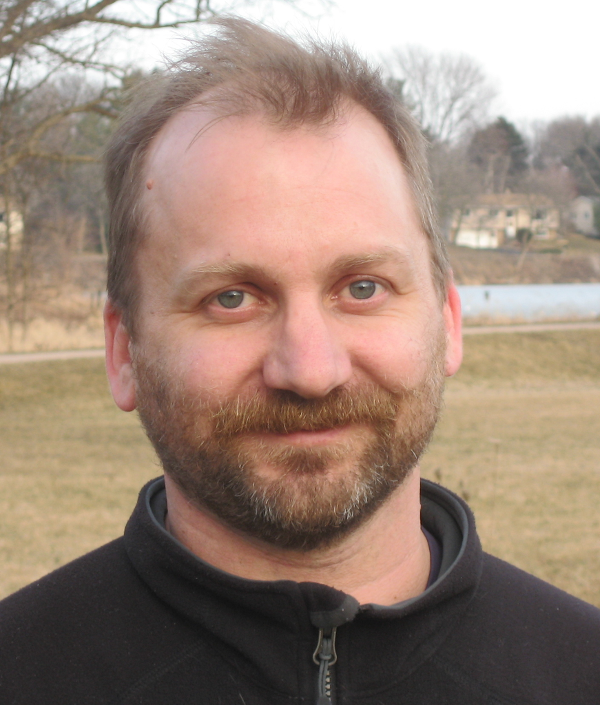

## Everything with a script

- A script is a sequence of code that performs a specific job
- Pointing, clicking, dragging, dropping, copying, pasting are not reproducible
- Code tracks and records every step you take
- Get data -> convert file -> edit file -> clean data -> analyze data
- Still possible to write terrible scripts though

## Organize your data and code

- Use one directory for one project
- Put code and data in separate subdirectories
- Use relative paths that refer only to the project directory and not to your specific computer
- This way if some one else opens the directory on their computer, the script still works
- Take a minute and choose file names carefully (more later)
- Avoid using *final* in a file name – nothing is ever final, ever
- Write ReadMe files – something that describes what is what

## Automate the process

- Aim to write a script of your scripts
- Rerunning your project happens with the touch of a button
- Broman recommends GNU Make, but R is sufficient for this course

## Turn scripts into reproducible reports

- Include enough text in your scripts that future you and anyone else will know why you did what you did
- We will devote time to reproducible reports later in the semester

## Turn repeated code into functions

- A function is a command made up of other code, e.g. mean
- Your code will be a lot easier to read and faster to write
- Package up these functions to share and use later

## Use version control

- You are already doing this!

## The real world

## Data collection

- Reproducibility begins before you head to the field or lab
- Establish a recorded protocol complete with references  
  +Test if everyone can follow the protocol before they are left on their own  
  +Bring the protocol with you to the field and record deviations +Name everything that is unique – each chamber Do not assume you will remember anything. Remembering indicates there is a piece of data that exists only in your head!
- Take notes on anything that might be slightly relevant, but don't go overboard – you should have established most of the required information before you got to the field
- Take pictures in the field/lab. . .you gotta

## Collected data

- If your data exists only on paper – scan or photograph the paper
- There will be an error and you'll need to refer back
- Make data entry as easy as possible for those entering data
- If data collection was automated, keep it just as it comes in  
  **Never manually change your raw data**

## That being said, back to Karl Broman for [spreadsheet organization](http://kbroman.org/dataorg/)

## Be consistent

- Use consistent codes for variable names
- Not "Soy", "soy", "Soybean"
- Use a single fixed code for any missing values
- NA, NAN, . . .
- Use consistent codes for categorical variables
- Location - "Arm", "Lewis", "Lew"  
  *Use common data layout if you have multiple files

## Write dates as YYYY-MM-DD

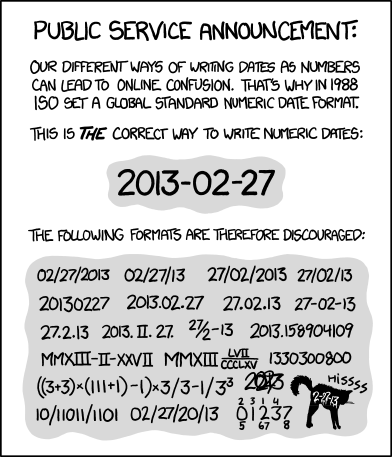

## Excel is a date monster

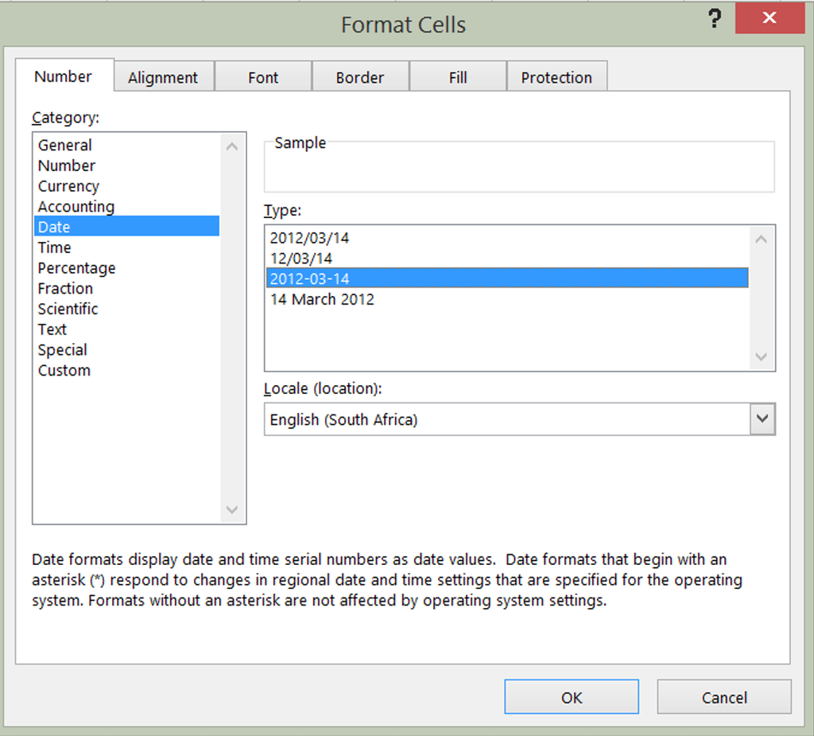